# B Cells FACS

## Load FACS B cells

```r
library(Seurat)
library(tidyverse)
library(here)
load(here('vignettes', 'bcells', 'facs_immune.Robj'))
source(here('vignettes', 'bcells', 'common.R'))
```

Run Principal Component Analysis.

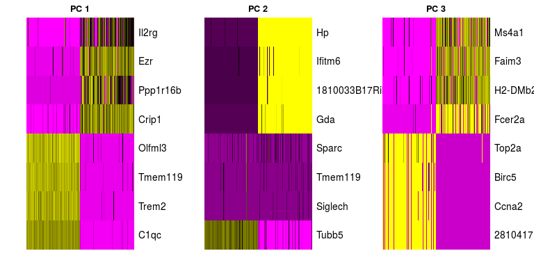

```r
tiss_facs_immune <- RunPCA(object = tiss_facs_immune, do.print = FALSE)
tiss_facs_immune <- ProjectPCA(object = tiss_facs_immune, do.print = FALSE)
PCHeatmap(object = tiss_facs_immune, pc.use = 1:3, cells.use = 500, do.balanced = TRUE, label.columns = FALSE, num.genes = 8)
```

Later on (in FindClusters and TSNE) you will pick a number of principal components to use. This has the effect of keeping the major directions of variation in the data and, ideally, supressing noise. There is no correct answer to the number to use, but a decent rule of thumb is to go until the plot plateaus.

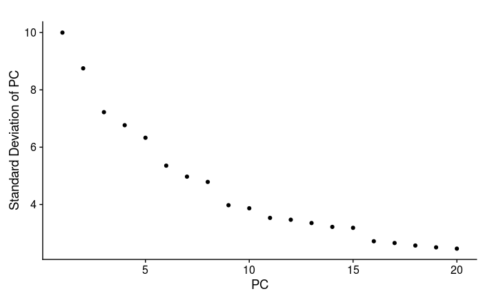

```r
PCElbowPlot(object = tiss_facs_immune)
```

We want to pick the PC number just *before* the plot plateaus, which to me looks like 15 PCs.

```r
# Set number of principal components.
n.pcs = 15
```

```r
# Set resolution
res.used <- .1
tiss_facs_immune <- FindClusters(object = tiss_facs_immune, reduction.type = "pca", dims.use = 1:n.pcs,
    resolution = res.used, print.output = 0, save.SNN = TRUE)
```

To visualize

```r
# If cells are too spread out, you can raise the perplexity. If you have few cells, try a lower perplexity (but never less than 10).
tiss_facs_immune <- RunTSNE(object = tiss_facs_immune, dims.use = 1:n.pcs, seed.use = 10, perplexity=30)
```

```r
tissue_colors_from_paper = read.csv('~/tabula-muris/00_data_ingest/15_color_palette/tissue_colors.csv', row.names=1,
         stringsAsFactors=FALSE)
tissues_in_data = sort(unique(as.character(tiss_facs_immune@meta.data$tissue)))
tissue_colors = tissue_colors_from_paper[tissues_in_data, "color"]
tissue_colors
```

```
 [1] "#ff7f0e" "#98df8a" "#d62728" "#ff9896" "#c5b0d5" "#8c564b" "#c49c94" "#f7b6d2" "#7f7f7f" "#c7c7c7"
[11] "#bcbd22" "#dbdb8d"
```

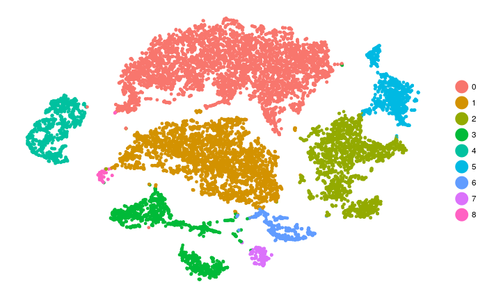

```r
TSNEPlot(tiss_facs_immune, no.axes=TRUE)
```

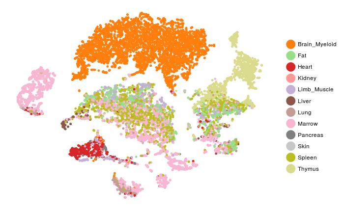

```r
TSNEPlot(tiss_facs_immune, group.by = 'tissue',  colors.use=tissue_colors, no.axes=TRUE)
```

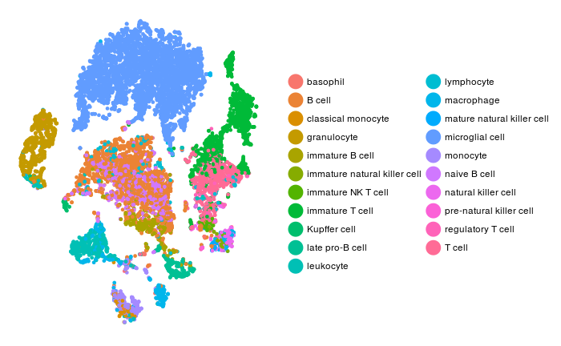

```r
TSNEPlot(tiss_facs_immune, group.by = 'cell_ontology_class', no.axes=TRUE)
```

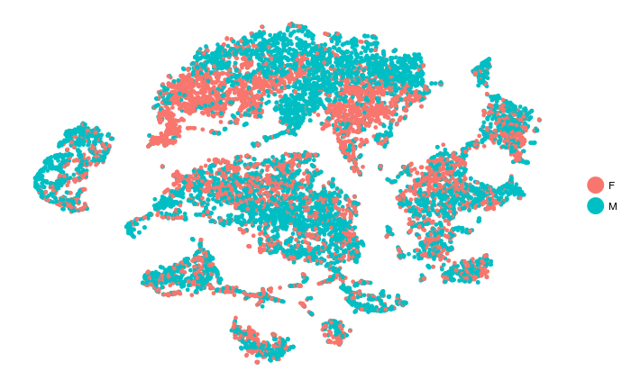

```r
TSNEPlot(tiss_facs_immune, group.by = 'mouse.sex', no.axes=TRUE)
```

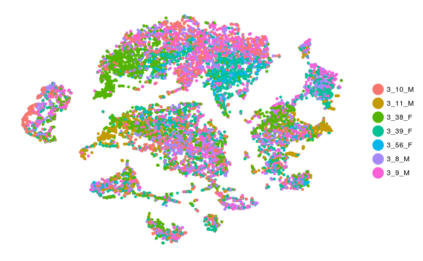

```r
TSNEPlot(tiss_facs_immune, group.by = 'mouse.id', no.axes=TRUE)
```

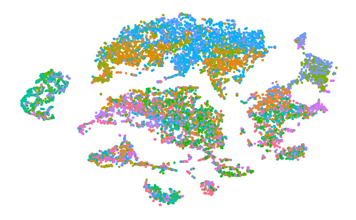

```r
TSNEPlot(tiss_facs_immune, group.by = 'plate.barcode', no.legend=TRUE, no.axes=TRUE)
```

```r
table(tiss_facs_immune@meta.data$cell_ontology_class, tiss_facs_immune@ident)
```

```
                                  0    1    2    3    4    5    6    7    8
  basophil                        0    0    6   17    0    0    1    1    0
  B cell                          8 1891   46   35   11    0   21    6   11
  classical monocyte              1    0    0   89    0    0    0    0    0
  granulocyte                     1    0    0    0  760    0    0    0    0
  immature B cell                 0  293    0    1    0    0   50    0    0
  immature natural killer cell    0    0   36    0    0    0    0    0    0
  immature NK T cell              0    0   37    0    0    0    0    0    0
  immature T cell                 3    0  564    0    0  769    0    0    1
  Kupffer cell                    0    0    0    5    2    0    0    1   53
  late pro-B cell                 5    3    0    0    0    0  298    0    0
  leukocyte                      13   20   39  510   43    0    2    0    0
  lymphocyte                      0   64   15    1    0    0    1    0    0
  macrophage                     16    1   47  160    5    0    0  166    0
  mature natural killer cell      0    0   49    0    0    0    0    0    0
  microglial cell              4389    2    0    1    0    0    0    0    2
  monocyte                        3    1    0  322    2    0    0    0    1
  naive B cell                    9  673    1    7    1    0    1    0    0
  natural killer cell             2    7  172    0    1    0    0    0    5
  pre-natural killer cell         0    0   21    0    0    0    1    0    0
  regulatory T cell               0    1   26    0    0    0    0    0    0
  T cell                          0    1  788    3    0    0    0    0    1
```

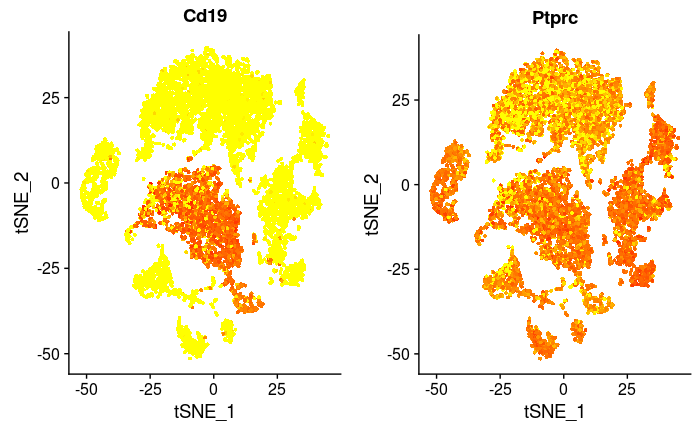

```r
genes_to_check= c('Cd19', 'Ptprc')
FeaturePlot(tiss_facs_immune, genes_to_check)
```

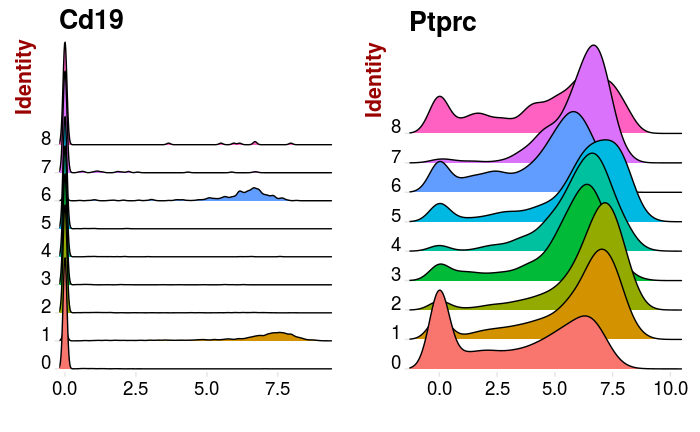

```r
RidgePlot(tiss_facs_immune, genes_to_check)
```

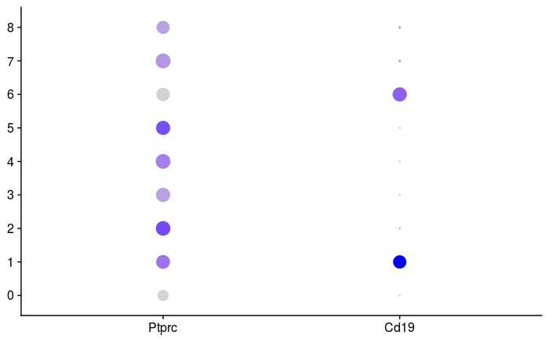

```r
DotPlot(tiss_facs_immune, genes_to_check)
```

Save the clustered immune cells for later.

```r
save(tiss_facs_immune, file=here('vignettes', 'bcells', 'facs_immune_clustered.Robj'))
```

```
|----|----|----|----|----|----|----|----|----|----|
```

```
[1] "Scaling data matrix"
```

```
|----|----|----|----|----|----|----|----|----|----|
|----|----|----|----|----|----|----|----|----|----|
```

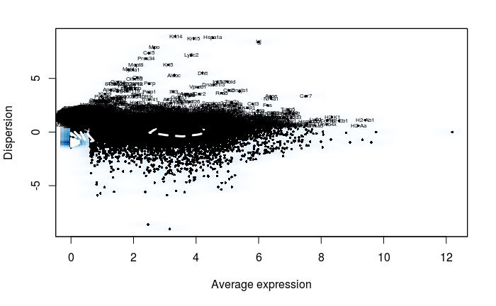

```r
tiss_facs_cd19 = SubsetData(object = tiss_facs_immune, ident.use = c(1, 6))
tiss_facs_cd19 = process_tissue(tiss_facs_cd19, scale=1e6)
```

Run Principal Component Analysis.

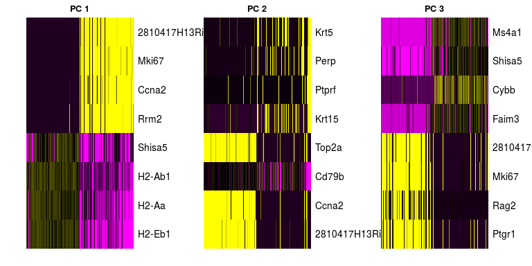

```r
tiss_facs_cd19 <- RunPCA(object = tiss_facs_cd19, do.print = FALSE)
tiss_facs_cd19 <- ProjectPCA(object = tiss_facs_cd19, do.print = FALSE)
PCHeatmap(object = tiss_facs_cd19, pc.use = 1:3, cells.use = 500, do.balanced = TRUE, label.columns = FALSE, num.genes = 8)
```

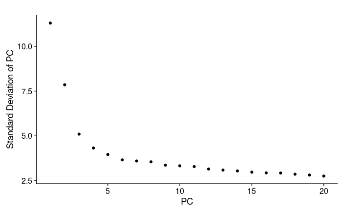

```r
PCElbowPlot(object = tiss_facs_cd19)
```

```r
# Set number of principal components.
sub.n.pcs = 5
```

The clustering is performed based on a nearest neighbors graph. Cells that have similar expression will be joined together. The Louvain algorithm looks for groups of cells with high modularity–more connections within the group than between groups. The resolution parameter determines the scale…higher resolution will give more clusters, lower resolution will give fewer.

For the top-level clustering, aim to under-cluster instead of over-cluster. It will be easy to subset groups and further analyze them below.

```r
# Set resolution
sub.res.used <- .1
tiss_facs_cd19 <- FindClusters(object = tiss_facs_cd19, reduction.type = "pca", dims.use = 1:sub.n.pcs,
    resolution = sub.res.used, print.output = 0, save.SNN = TRUE)
# If cells are too spread out, you can raise the perplexity. If you have few cells, try a lower perplexity (but never less than 10).
tiss_facs_cd19 <- RunTSNE(object = tiss_facs_cd19, dims.use = 1:sub.n.pcs, seed.use = 10, perplexity=30)
```

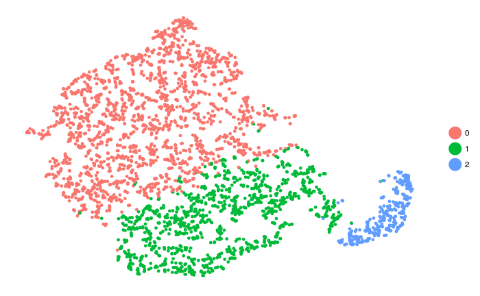

```r
TSNEPlot(tiss_facs_cd19, no.axes=TRUE)
```

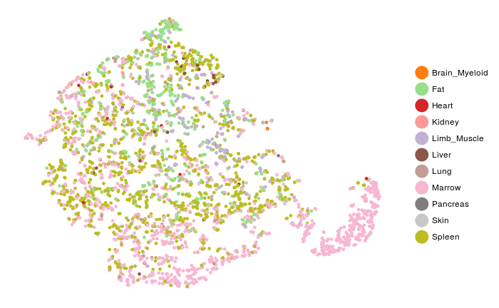

```r
TSNEPlot(tiss_facs_cd19, group.by = 'tissue',  colors.use=tissue_colors, no.axes=TRUE)
```

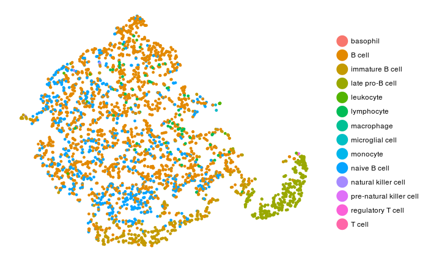

```r
TSNEPlot(tiss_facs_cd19, group.by = 'cell_ontology_class', no.axes=TRUE)
```

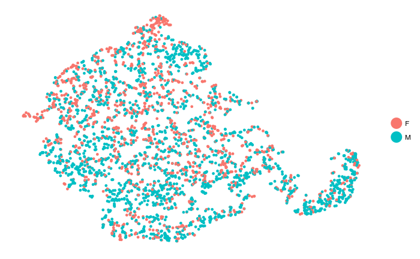

```r
TSNEPlot(tiss_facs_cd19, group.by = 'mouse.sex', no.axes=TRUE)
```

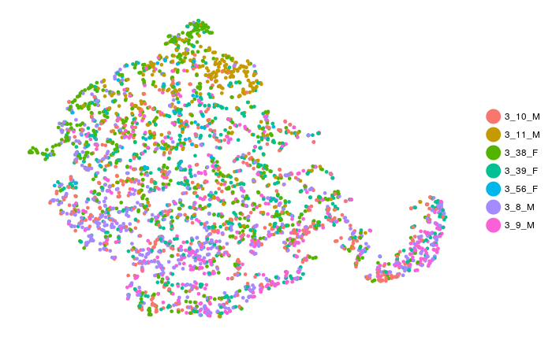

```r
TSNEPlot(tiss_facs_cd19, group.by = 'mouse.id', no.axes=TRUE)
```

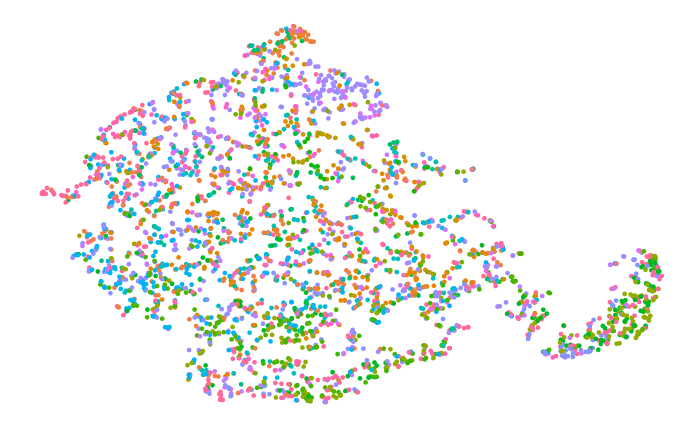

```r
TSNEPlot(tiss_facs_cd19, group.by = 'plate.barcode', no.legend=TRUE, no.axes=TRUE)
```

```r
table(tiss_facs_cd19@meta.data$tissue, tiss_facs_cd19@ident)
```

```
                  0   1   2
  Brain_Myeloid   2   0   0
  Fat           422  90   2
  Heart           9   1   1
  Kidney          6   0   0
  Limb_Muscle   109  26   0
  Liver          28   3   0
  Lung           38  18   0
  Marrow        451 593 281
  Pancreas        0   2   0
  Skin            9   0   0
  Spleen        832 402   7
```

```r
table(tiss_facs_cd19@meta.data$cell_ontology_class, tiss_facs_cd19@ident)
```

```
                             0    1    2
  basophil                   0    0    1
  B cell                  1375  527   10
  immature B cell           27  310    6
  late pro-B cell            0   29  272
  leukocyte                 18    3    1
  lymphocyte                51   14    0
  macrophage                 1    0    0
  microglial cell            2    0    0
  monocyte                   1    0    0
  naive B cell             422  252    0
  natural killer cell        7    0    0
  pre-natural killer cell    0    0    1
  regulatory T cell          1    0    0
  T cell                     1    0    0
```

```
[1] "Finished averaging RNA for cluster 0"
[1] "Finished averaging RNA for cluster 1"
[1] "Finished averaging RNA for cluster 2"
```

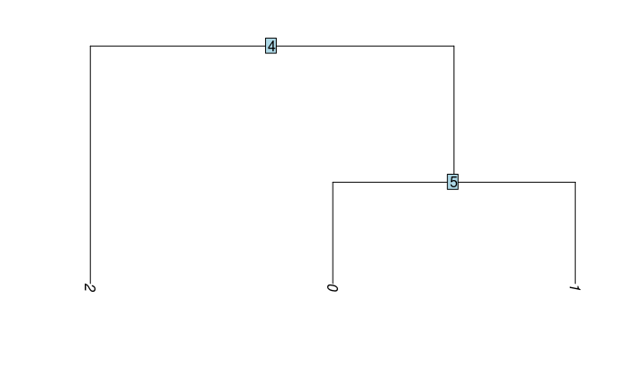

```r
tiss_facs_cd19 = BuildClusterTree(tiss_facs_cd19)
```

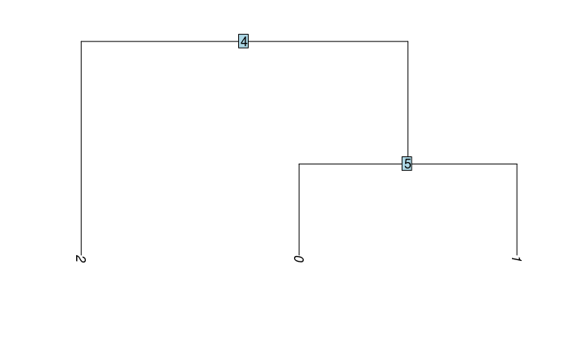

```r
PlotClusterTree(tiss_facs_cd19)
```

## Save cluster identities

```r
tiss_facs_cd19@meta.data[,'original.cluster.ids'] = as.numeric(tiss_facs_cd19@ident)
```

## Save the Robj for later

```r
save(tiss_facs_cd19, file = here('vignettes', 'bcells', 'facs_cd19.Robj'))
```